# Project 2: Airplane Passenger Satisfaction Predictions

## 1. Introduction

### a. Set up

Before beginning with our project, it is necessary to load all the R-Studio packages we will be utilizing.

### b. Quick description of the dataset

The dataset chosen for this exploration is titled “Airline Passenger Satisfaction” and was downloaded from the kaggle data repository website (https://www.kaggle.com/datasets/teejmahal20/airline-passenger-satisfaction). The original source of this dataset is unknown, but it details airplane passenger information. Each row represents an individual passenger, whereas each column details a different aspect of the passenger, such as gender and age, but also other information, such as the type of flight (business or personal), their satisfaction(satisfied or neutral/dissatisfied), and their ratings of many of the airplanes amenities.

```r
# Import datasets
library(readr)
test <- read_csv("test.csv")
train <- read_csv("train.csv")

# Merge the two csv files
airplane <- bind_rows(test, train) %>%
  select(-id, -...1) # ID and Row Number will not be utilized

# Mutate outcome variables we will be looking at ##
airplane_type <- airplane %>%
  mutate(satisfaction = ifelse(satisfaction == "satisfied", 1, 0),
         `Type of Travel` = ifelse(`Type of Travel` == "Business travel", 1, 0)) %>%
  select_if(is.numeric) %>%
  na.omit # remove any surveys with NA values
```

The datasets were originally two separate datasets, with one ‘train’ set and one ‘test’ set. The two were combined and then the variables of `ID` and `...1` (sample numbering column) were extracted since they would be irrelevant to the analysis.

Next, the binary variables mentioned previously were converted into numeric binary variables. The satisfaction variable was altered so that a satisfaction response of ‘satisfied’ equaled 1, while a response of ‘neutral/dissatisfied’ equaled 0. Similarly, the `Type of Travel` column was mutated so that `Business travel` equaled 1, and `Personal travel` equaled 0.

Then, non-numeric, categorical variables were filtered out since only numeric data was desired in order to construct the prediction models in the downstream steps of analysis.

```r
# Take a look
head(airplane_type)
```

```
## # A tibble: 6 × 20
##     Age Type o…¹ Fligh…² Infli…³ Depar…⁴ Ease …⁵ Gate …⁶ Food …⁷ Onlin…⁸ Seat …⁹
##   <dbl>    <dbl>   <dbl>   <dbl>   <dbl>   <dbl>   <dbl>   <dbl>   <dbl>   <dbl>
## 1    52        1     160       5       4       3       4       3       4       3
## 2    36        1    2863       1       1       3       1       5       4       5
## 3    20        1     192       2       0       2       4       2       2       2
## 4    44        1    3377       0       0       0       2       3       4       4
## 5    49        1    1182       2       3       4       3       4       1       2
## 6    16        1     311       3       3       3       3       5       5       3
## # … with 10 more variables: `Inflight entertainment` <dbl>,
## #   `On-board service` <dbl>, `Leg room service` <dbl>,
## #   `Baggage handling` <dbl>, `Checkin service` <dbl>,
## #   `Inflight service` <dbl>, Cleanliness <dbl>,
## #   `Departure Delay in Minutes` <dbl>, `Arrival Delay in Minutes` <dbl>,
## #   satisfaction <dbl>, and abbreviated variable names ¹`Type of Travel`,
## #   ²`Flight Distance`, ³`Inflight wifi service`, …
```

### c. Define research questions

For our explorations, we wanted to consider the ways in which Overall Satisfaction and Type of Travel could be predicted using the results of the surveys. Thus, the following two research questions were developed:

1. Can survey results for Wifi Service, Cleanliness, and Leg Room Service, and Arrival Delay, predict the overall Satisfaction reported by passengers?
2. Can satisfaction of Online Boarding and Cleanliness, Age, and Flight Distance predict the Type of Travel?

For this analysis, the binary variables `satisfaction` and `Type of Travel` were chosen to be predicted based on other numeric variables in the dataset. It was predicted that higher passenger survey ratings and lesser delay times would correspond to a ‘satisfied’ passenger response. It was also predicted that perhaps those undergoing a Business Trip are likely to take longer flights, be of an older demographic, and are likely to report more strictly on the satisfaction surveys. In contrast, Personal Trip passengers would be more likely to have shorter flights, be of a wider-age demographic and additionally give the wider range of satisfaction results.

## 2. Exploratory Data Analysis

We begin by first taking a look at the Correlation Matrix of all the numerical variables in our dataset:

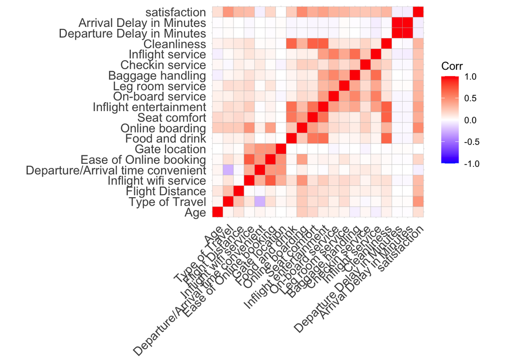

```r
# generating a correlation matrix to investigate the relationship, if any, between the numeric variables in the dataset
ggcorrplot(cor(airplane_type))
```

After reviewing the correlation matrix, apart from the high correlation between the variables and themselves (which is as expected), the variables of arrival time and departure time also demonstrate a high correlation. However, this is intuitive since the amount by which a passenger is delayed in their departure would be the amount by which they are delayed in their arrival. Apart from these variables, the variable `Cleanliness` appears to have a moderate positive correlation with the variables `Inflight entertainment`, `Seat comfort`, and `Food and drink`.

Next we will consider 4 different visualizations, depicting the relationship between these different variables:

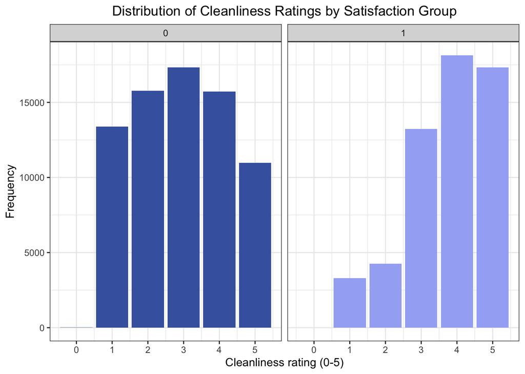

```r
## ggplot1: exploration of relationship bewtween satisfaction group and cleanliness ratings
ggplot(airplane_type, aes(fill = as.factor(satisfaction), x = Cleanliness)) +
  geom_bar() +
  # to label every rating category from 0 - 5
  scale_x_continuous(breaks = seq(0, 5, 1), labels = seq(0, 5, 1)) +
  # facetting the plots to show responses by satisfaction group
  facet_wrap(~satisfaction) +
  labs(fill = 'Satisfaction', x = 'Cleanliness rating (0-5)',
       y = 'Frequency',
       title = 'Distribution of Cleanliness Ratings by Satisfaction Group') +
  scale_fill_manual(values = c('#4464AD', '#A4B0F5')) +
  theme_bw() +
  # centering plot title and removing color legend
  theme(plot.title = element_text(hjust = 0.5), legend.position = 'none')
```

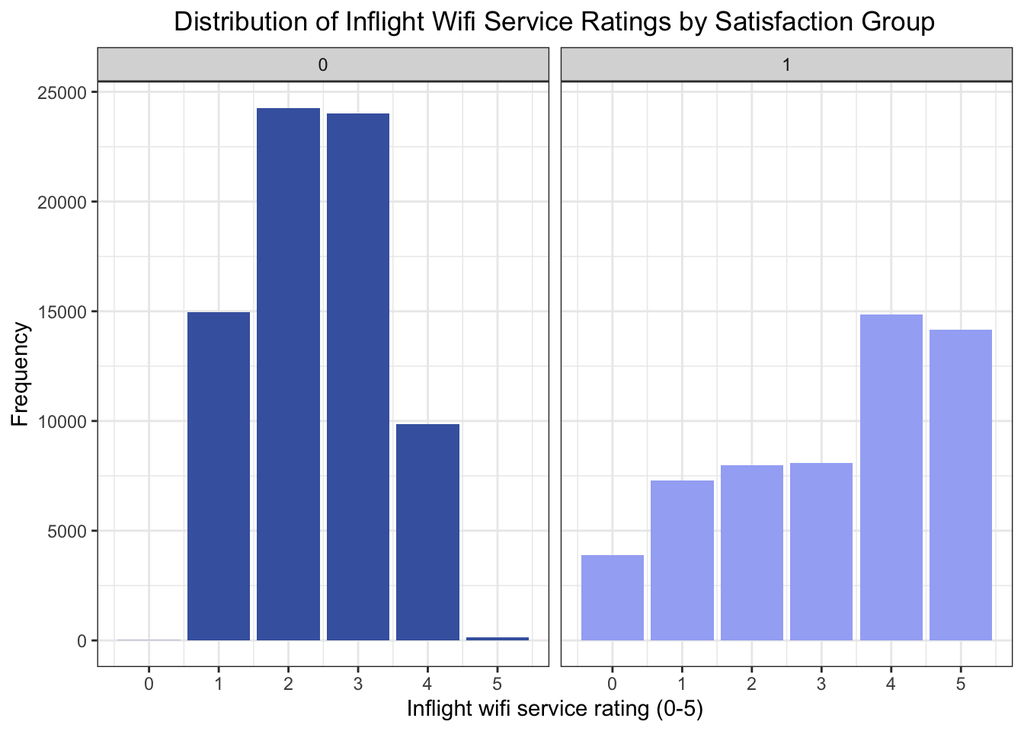

```r
## ggplot2: exploration of relationship bewtween satisfaction group and inflight wifi service ratings
ggplot(airplane_type, aes(fill = as.factor(satisfaction), x = `Inflight wifi service`)) +
  geom_bar() +
  scale_x_continuous(breaks = seq(0, 5, 1), labels = seq(0, 5, 1)) +
  facet_wrap(~satisfaction) +
  labs(fill = 'Satisfaction',
       x = 'Inflight wifi service rating (0-5)',
       y = 'Frequency',
       title = 'Distribution of Inflight Wifi Service Ratings by Satisfaction Group') +
  scale_fill_manual(values = c('#4464AD', '#A4B0F5')) +
  theme_bw() +
  theme(plot.title = element_text(hjust = 0.5), legend.position = 'none')
```

These plots demonstrate the frequencies of passenger responses regarding certain flight aspects. Passengers rated each amenity and/or aspect based on the discrete ranking scale of 0 to 5. Passenger responses were then divided by satisfaction group, where 0 represents the neutral/unsatisifed group, and 1 represents the satisfied group.

As demonstrated in these bar charts, there appears to be a relationship between the satisfaction grouping and the ratings given by the passengers for these. In general, there appears to be a greater frequency of higher rating values for the satisfied group (group 1) when compared to the neutral/unsatisfied group (group 0). Conversely, a greater frequency of lesser rating reports is demonstrated for the neutral/unsatisfied group in comparison to the satisfied group.

Now, consider the following visualization, depicting the relationship between the Type of Travel taken by a passenger and their Online Boarding satisfaction rating.

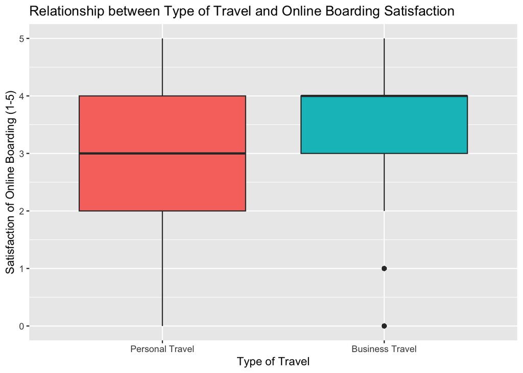

```r
## ggplot 3: Explore the relationship between type of Travel and Online Boarding
airplane_type %>%
  ggplot(aes(x = as.factor(`Type of Travel`),
             y = `Online boarding`,
             fill = as.factor(`Type of Travel`))) +
  geom_boxplot() +
  labs(title = "Relationship between Type of Travel and Online Boarding Satisfaction",
       y = "Satisfaction of Online Boarding (1-5)",
       x = "Type of Travel",
       fill = "Type of Travel") +
  scale_x_discrete(labels = c("Personal Travel", "Business Travel")) +
  theme(legend.position = "none")
```

The boxplot seems to suggest that the median rating for those on a Business Trip is higher than the median rating for Personal Trips. Additionally, the range of ratings for Business Trips appears to be smaller than the range for that of Personal Travel. This suggests that perhaps those traveling for business purposes are more likely to report a higher satisfaction of online boarding than passengers under personal travel. This seems to be as expected, since those undergoing personal travel are likely to focus their attention more on the destinations of their travels rather than their on-board experience.

In addition to online boarding ratings, the following box plot explores the relationship between the Type of Travel and the Age of the passenger.

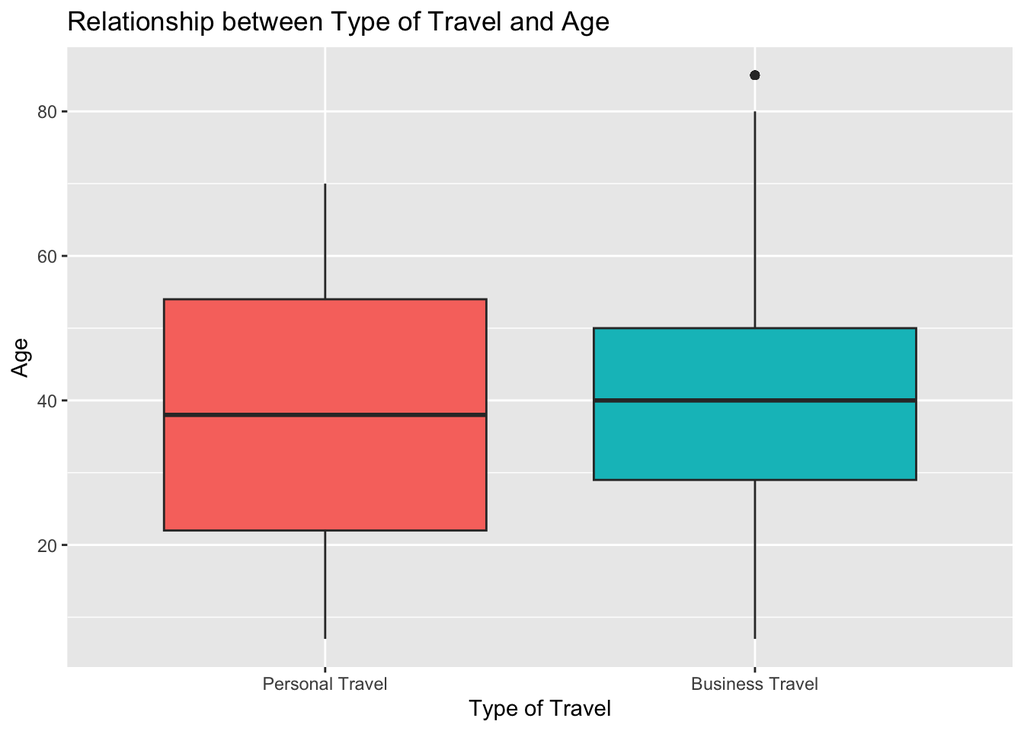

```r
## ggplot 4: Explore the relationship between type of Travel and Age
airplane_type %>%
  ggplot(aes(x = as.factor(`Type of Travel`),
             y = Age,
             fill = as.factor(`Type of Travel`))) +
  geom_boxplot() +
  labs(title = "Relationship between Type of Travel and Age",
       y = "Age",
       x = "Type of Travel",
       fill = "Type of Travel") +
  scale_x_discrete(labels = c("Personal Travel", "Business Travel")) +
  theme(legend.position = "none")
```

According to the boxplots, groups of passengers from both types of travel seem to have similar median ages. However, the Interquartile Range of ages for Business Travel passengers appears to be smaller than the IQR for Personal Travel, perhaps indicating that personal travel flights are taken by a wider age range of passengers compared to those for business travel flights, which would make sense since a personal travel flight can be taken at any time in a person’s life.

## 3. Prediction and Cross-Validation

### a. Research Question 1:

For investigating if overall passenger satisfaction is affected by survey data for wifi service, cleanliness, leg room service, and arrival delay, a logistic regression madel was constructed.

```r
# using the entire dataset in order to construct a logistic regression model
airplane_log <- glm(satisfaction ~ `Inflight wifi service` +
                      Cleanliness + `Leg room service` + `Arrival Delay in Minutes`, data = airplane_type, family = "binomial")

summary(airplane_log)
```

```
##
## Call:
## glm(formula = satisfaction ~ `Inflight wifi service` + Cleanliness +
##     `Leg room service` + `Arrival Delay in Minutes`, family = "binomial",
##     data = airplane_type)
##
## Deviance Residuals:
##     Min       1Q   Median       3Q      Max
## -2.1756  -0.9291  -0.4392   0.9493   2.9589
##
## Coefficients:
##                             Estimate Std. Error z value Pr(>|z|)
## (Intercept)                -4.678346   0.030811 -151.84   <2e-16 ***
## `Inflight wifi service`     0.396093   0.004980   79.53   <2e-16 ***
##  [ reached getOption("max.print") -- omitted 3 rows ]
## ---
## Signif. codes:  0 '***' 0.001 '**' 0.01 '*' 0.05 '.' 0.1 ' ' 1
##
## (Dispersion parameter for binomial family taken to be 1)
##
##     Null deviance: 177279  on 129486  degrees of freedom
## Residual deviance: 145326  on 129482  degrees of freedom
## AIC: 145336
##
## Number of Fisher Scoring iterations: 4
```

With this logistic model, a ROC curve is constructed in order to determine the accuracy the logistic model has in predicting the satisfaction reported by passengers.

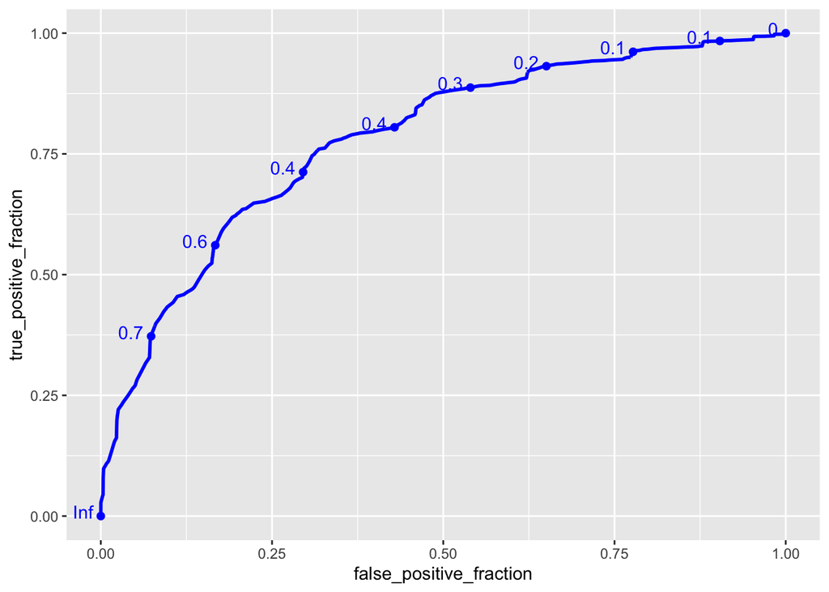

```r
logistic_ROC <- ggplot(airplane_type) +
  geom_roc(aes(d = satisfaction,
               m = predict(airplane_log, type = 'response')),
           color = 'blue')

# visualize ROC curve
logistic_ROC
```

```r
# calculate the area under the curve
calc_auc(logistic_ROC)$AUC
```

```
## [1] 0.7791951
```

The value of the AUC was calculated to be about 0.78, meaning that after being trained on the entire data set, the logistic model had a fairly decent accuracy when predicting satisfaction group.

in order to determine if this accuracy rate was relatively stable among ‘new’ data sets, A 10-fold cross validation is then conducted on this logistical model .

```r
airplane_logistic_cv <-
  train(as.factor(satisfaction) ~ `Inflight wifi service` + Cleanliness + `Leg room service` + `Arrival Delay in Minutes`,
      data = airplane_type,
      # Type of model
      method = "glm",
      # Cross validation: 10 folds
      trControl = trainControl(method = "cv", number = 10),
      family = "binomial")

airplane_logistic_cv
```

```
## Generalized Linear Model
##
## 129487 samples
##      4 predictor
##      2 classes: '0', '1'
##
## No pre-processing
## Resampling: Cross-Validated (10 fold)
## Summary of sample sizes: 116538, 116538, 116538, 116538, 116539, 116538, ...
## Resampling results:
##
##   Accuracy   Kappa
##   0.7241963  0.4324441
```

After performing the test, an average accuracy rate of 72% was calculated. Thus, it appears that the model does a fairly decent job when dealing with new, untrained datasets, though there was a slight decrease in accuracy when compared to the model trained on the entire data set. While not a tremendous decrease, this may be an indication of slight overfitting.

### b. Research Question 2: Predicting Type of Travel

For investigating if the type of travel taken by passengers can be predicted, a Decision Tree model is considered, using Online Boarding, Age, Flight Distance, and Cleanliness as predictor variables.

```r
## Use the entire dataset to fit A Decision Tree Model ##
airplane_type_tree <- rpart(`Type of Travel` ~ `Online boarding` + Age + `Flight Distance` + `Cleanliness`,
                      data = airplane_type,
                      method = "class")
```

With this decision tree model, a ROC curve is constructed in order to determine the accuracy the Decision Tree model has in correctly predicting the type of flight taken by the passengers.

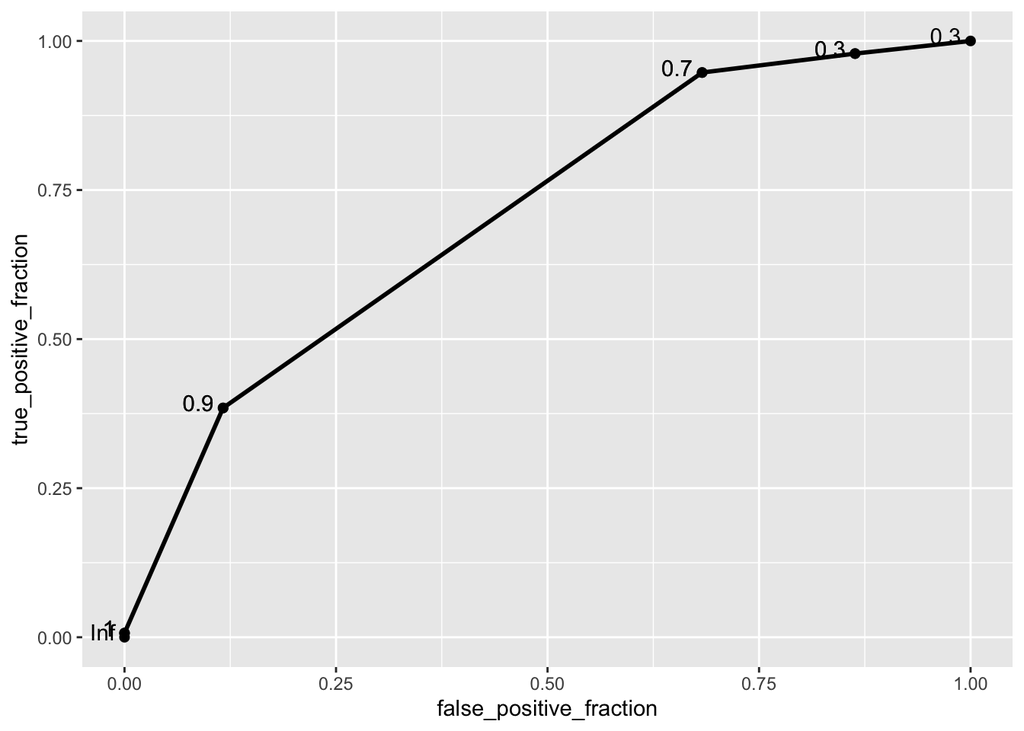

```r
## Build a ROC curve for our Decision Tree ##
ROC <- ggplot(airplane_type)+
  geom_roc(aes(d = `Type of Travel`, m = predict(airplane_type_tree, airplane_type)[,2]))

# Visualize ROC Curve
ROC
```

```r
# Value of AUC
calc_auc(ROC)$AUC
```

```
## [1] 0.7088982
```

According to the ROC curve, the Decision Tree Model carries an accuracy of approximately 70.89%. While this is not as high as expected, the accuracy suggests that the model is correct for most of its predictions.

To determine how well the Decision Tree model is at predicting new data, 10-Fold Cross-Validation will be utilized. To do so, a for loop is constructed in order to divide our dataset into test and train sets.

```r
### 10-Fold Cross-Validation: Test/Train sets using a For-Loop
# Choose number of folds:
k = 10

# Randomly order rows in the dataset:
data <- airplane_type[sample(nrow(airplane_type)), ]

# Create k folds:
folds <- cut(seq(1:nrow(data)), breaks = k, labels = FALSE)

# Initialize a vector to keep track of the performance:
perf_k <- NULL

# Use a for loop to get performance for each test set:
for(i in 1:k){
  # Create train and test sets
    train_not_i <- data[folds != i, ]
    test_i <- data[folds == i, ]

  # Train model on train set (all but fold i)
    model_i<- rpart(`Type of Travel` ~ `Online boarding` + Age + `Flight Distance`,
                      data = train_not_i,
                      method = "class")

  # Test model on test set (fold i)
    predict_i <- test_i %>%
      mutate(predictions = predict(model_i, test_i)[,2])
  # Consider the ROC curve for the test dataset
    ROC <- ggplot(predict_i) + geom_roc(aes(d = `Type of Travel`, m = predictions))

  # Get performance for fold i (AUC)
    perf_k[i] <- calc_auc(ROC)$AUC}

# Average performance:
mean(perf_k)
```

```
## [1] 0.7082906
```

## 4 & 5. Dimension Reduction and Clustering

In order to to analyze the relationship between all of the variables in the dataset in a more robust manner, a principal component analysis was conducted. A correlation circle was also created to interpret the first 2 Principal Components constructed.

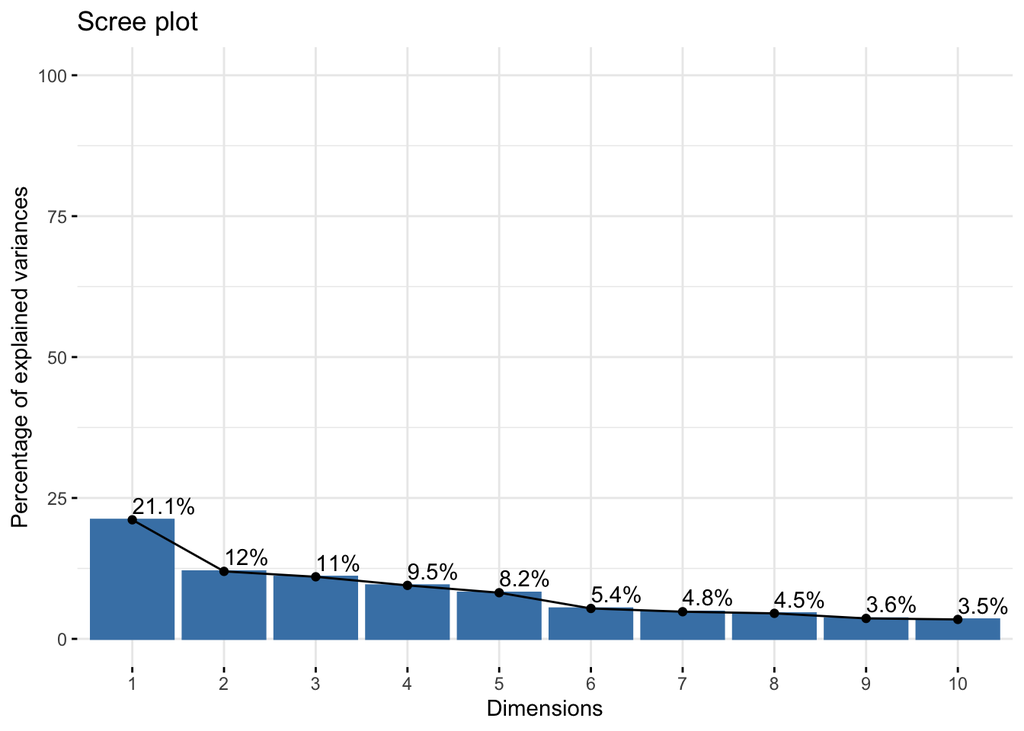

```r
###  Perform PCA with prcomp() ###
# Prepare the dataset
airplane_stype<- airplane_type %>%
  scale %>%
  as.data.frame()

# Unfortunately, the data is too big, so we will look at a random sample
set.seed(10)

airplane_sample <- airplane_stype %>%
  slice_sample(n = 6474) # we will look at 5% of the dataset

# PCA performed with the function prcomp()
pca_type <- airplane_sample %>%
  prcomp()

# Visualize percentage of variance explained for each PC in a scree plot
fviz_eig(pca_type, addlabels = TRUE, ylim = c(0, 100))
```

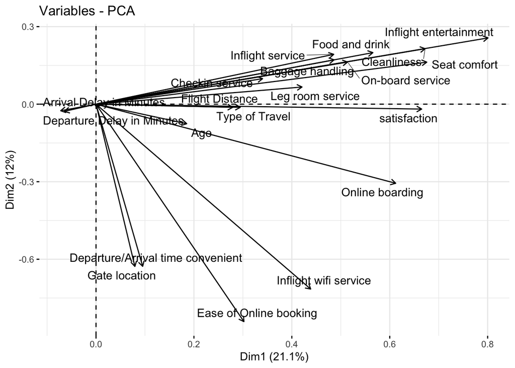

```r
# Interpreting the first 2 PCs using a Correlation Circle
fviz_pca_var(pca_type, col.var = "black",
             repel = TRUE) # Avoid text overlapping of the variable names
```

Looking at the Scree Plot produced, we find that in order to reach 80% of explained variance, we would need to keep the first 9 Principal Components for 80.1% of variance explained. In addition to the scree plot, the Correlation Circle seems to group up the variables:

- For our first prinicpal component, it seems that only the delay variables (Arrival/Departure) contribute negatively while all other variables contribute positively.
- For our second principal component, one group can be thought of as internet-associated amenities (`Inflight wifi service`, `Online boarding`, …), whereas another group can be thought of as airplane-ride associated services (`Seat comfort`, `Food and drink`, …)

To investigate whether the data naturally formed any groups, Clustering was performed with using k-means. To identify the number of clusters to identify, the following plot was constructed to maximize the silhouette width.

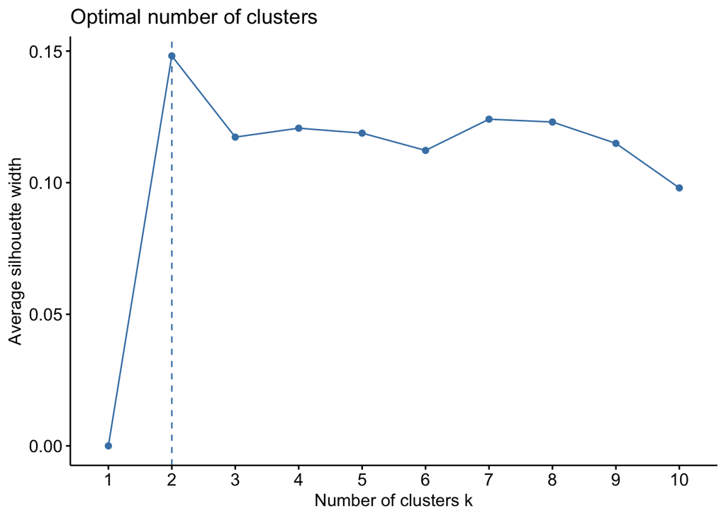

```r
### Perform Clustering with kmeans() ###
# Prepare the data: airplane_sample

# Number of Clusters: Maximize the silhouette while keeping a small number of clusters
fviz_nbclust(airplane_sample, kmeans, method = "silhouette")
```

According to the plot, the number of clusters we should look for is 2. Thus, the clustering algorith was applied, with K=2.

```r
# Apply the Algorithm: Using result from our silhouette plot, use the function kmeans() to find clusters
kmeans_results <- airplane_sample %>%
  kmeans(centers = 2) # centers sets the number of clusters to find

kmeans_results$centers # centers: Summary about the centers
```

[output not shown]

According to the results of the algorithm, our first cluster center (1) appears to be generally below average in most of the variables while our second cluster center (2) appears to be above average in most of the variables.

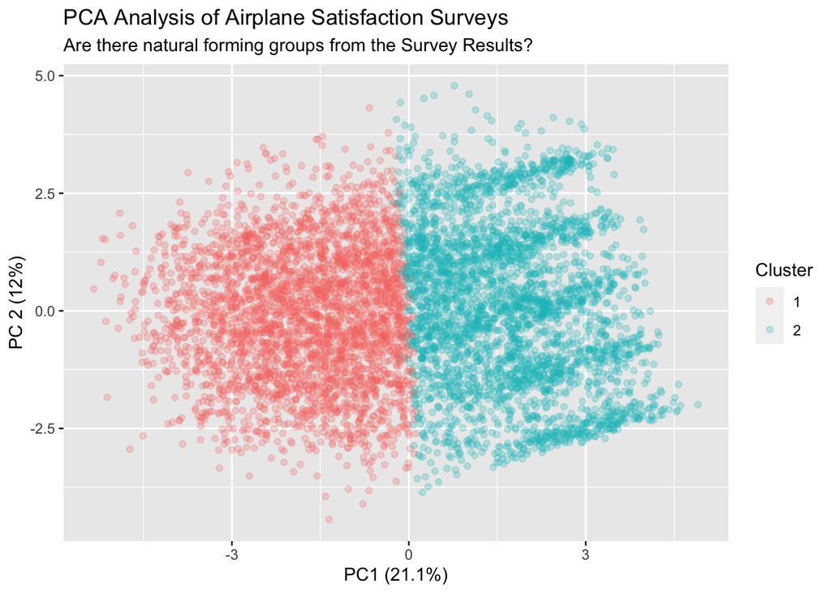

```r
# Visualize the Clusters
pca_type$x %>%
  as.data.frame() %>%
  mutate(cluster = kmeans_results$cluster) %>%

  ggplot(aes(x = PC1, y = PC2, color = as.factor(cluster))) +
  geom_point(alpha = 0.25) +
  labs(
    title = "PCA Analysis of Airplane Satisfaction Surveys",
    subtitle = "Are there natural forming groups from the Survey Results?",
    color = "Cluster",
    x = "PC1 (21.1%)",
    y = "PC 2 (12%)"
  )
```

From the clusters depicted in the visualization, it seems that the difference between the two clusters is primarily based on the first principal component. Reviewing the Correlation Circle produced prior to the cluster visualization, it can be interpreted that Cluster 1 (in red) is perhaps the surveys of Unsatisfied passengers, who reported high values for delay and lower satisfaction ratings for amenities, while Cluster 2 is the surveys of Satisfied passengers, who reported little to no arrival/departure delay and higher satisfaction ratings for amenities. Thus, the clusters seem to most closely represent our original variable `satisfaction`.

## 6. Discussion

### a. Reflections

**Research Question 1:**

Upon completing this analysis, it appears that Cleanliness, Arrival Delay in Minutes, and Inflight Wifi Service ratings can predict passenger satisfaction with a fairly high accuracy. The bar plots constructed demonstrated that satisfied passengers exhibited a negative skew in their survey responses, whereas the neutral/unsatisfied group demonstrated a positive skew in their responses. Furthermore, after constructing a logistic regression model using the hypothesized variables, an AUC of approximately 0.78 was found after training the model on the whole data set, whereas a 10-fold cross validation resulted in an accuracy of about 72%. Thus the model does fairly well at predicting passenger satisfaction, though, other variables should be investigated since there may be other predictors that are more indicative of a certain satisfaction group versus another.

In order to construct the model, it was difficult to decide what the best predictors would be in order to predict passenger satisfaction. However, after choosing the intended predictors, the process of exploring the data through visualizations, constructing a correlation matrix, and creating the model were all highly informative processes. Being able to tailor each step to our specific data set was confusing at times, but figuring out how to do so was a very valuable learning experience.

**Research Question 2:**

Analysis of the Dimension Reduction and Clustering parts were among the hardest points of the analysis. On top of the low amount of variation explained by each Component, it seems that our initial dataset was too big to run through the clustering process. Due to this, it was necessary to sample 5% of the original dataset. This would of course result in varying results and thus further explorations should consider methods to decrease this variation.

### b. Contributions

**Erick Gracia:**

- Responsible for the analysis of Research Question 2 (model fit, ROC Curve, Cross-Validation), the application of Dimension Reduction via principal components, and the application of the k-means Clustering method.

**Nicholas Calzada:**

- Responsible for the analysis of Research Question 1 (model fit, ROC Curve, Cross-Validation), the communication of the initial dataset in the Introduction, results found from the data exploration, and for the construction of the Correlation Matrix.